# K-pop; Wielka trójka wytwórni

## Czym jest k-pop?

K-pop (ang. *korean pop*) to gatunek muzyki wywodzący się z Korei Południowej, który łączy w sobie elementy innych gatunków takich jak rock, jazz, hip-hop, rhythm and blues a nawet z muzyki klasycznej. Oprócz śpiewu i rapu, bardzo ważnym elementem jest część wizualna , czyli kolorowe stroje oraz zsynchronizowane choreografie taneczne, których tempo dopasowywane jest do piosenki.

[figure not shown]

Rysunek 1: Zdjęcie zespołu K-pop Ateez

Zwiększone zainteresowanie kulturą Korei Południowej spowodowane globalnym rozprzestrzenianiem się seriali koreańskich oraz K-popu skłoniło rząd Korei do uznania korzyści dla sektora eksportowego kraju. Dzięki temu rząd zaczął wspierać przemysły kreatywne poprzez subwencje (tj. bezzwrotną pomoc finansową) oraz dofinansowania dla startupów.

Prócz czerpania korzyści ekonomicznych, rząd Korei wykorzystuje wpływ K-popu na dyplomację. Osiąganie celu poprzez przekonanie interesariuszy za pomocą atrakcyjności własnej kultury, czy ideałów (*soft power*) uważane jest za bardziej skuteczną taktykę dyplomatyczną niż tradycyjne osiąganie celu poprzez bezpośrednie zastraszanie (*hard power*).

## Wytwórnie rozrywkowe w Korei Południowej

Popularność k-popu sprawiła, że w Korei zaczęły powstawać coraz to nowe wytwórnie rozrywkowe. Zajmują się one rekrutacją, finansowaniem, szkoleniem, marketingiem oraz zarządzaniem działalnością muzyczną swoich artystów. Spośród nich najbardziej znane są: SM Entertainment, YG Entertainment oraz JYP Entertainment nazywane również “Wielką Trójką” ze względu na ich sprzedaż oraz przychody. Te firmy założyli: Lee Soo-man, Yang Hyun-suk (ps. Yang-gun) oraz Park Jin-young a od ich inicjałów pochodzą nazwy wymienionych wytwórni

## Przychody “Wielkiej Trójki”

Poniżej zostaną przedstawione tabele przychodów poszczególnych wytwórni, a następnie zostaną one porównane ze sobą.

Tabela 1: Przychody JYP i ich wzrost w latach 2017-2021

| Rok | Przychód (mln KRW) | Wzrost przychodu (%) | Zysk brutto (mln KRW) | Wzrost brutto (%) | EBIT (mln KRW) | Zysk netto (mln KRW) | Wzrost netto (%) | EBT (mln KRW) | Wzrost EBT (%) | EBITDA (mln KRW) | Wzrost EBITDA (%) |
| --- | --- | --- | --- | --- | --- | --- | --- | --- | --- | --- | --- |
| 2021 | 193,900 | 34.28 | 100,225 | 36.37 | 57,896 | 67,461 | 128.42 | 71,227 | 87.05 | 62,586 | 29.82 |
| 2020 | 144,399 | -7.10 | 73,498 | 0.08 | 44,138 | 29,534 | -5.65 | 38,079 | -11.61 | 48,209 | 2.85 |
| 2019 | 155,436 | 24.53 | 73,441 | 32.86 | 43,306 | 31,302 | 31.27 | 43,082 | 42.66 | 46,872 | 54.10 |
| 2018 | 124,821 | 22.08 | 55,277 | 41.77 | 29,259 | 23,845 | 47.41 | 30,199 | 43.34 | 30,417 | 36.40 |
| 2017 | 102,242 |  | 38,990 |  | 19,461 | 16,176 |  | 21,068 |  | 22,300 |  |

Źródło: Dane pozyskane ze strony wsj.com  
*Earnings Before deducting Interest and Taxes  
**Earnings Before Taxes  
***Earnings Before Interest, Taxes, Depreciation and Amortization

Tabela 2: Przychody YG i ich wzrost w latach 2017-2021

| Rok | Przychód (mln KRW) | Wzrost przychodu (%) | Zysk brutto (mln KRW) | Wzrost brutto (%) | EBIT (mln KRW) | Zysk netto (mln KRW) | Wzrost netto (%) | EBT (mln KRW) | Wzrost EBT (%) | EBITDA (mln KRW) | Wzrost EBITDA (%) |
| --- | --- | --- | --- | --- | --- | --- | --- | --- | --- | --- | --- |
| 2021 | 355,631 | 39.32 | 102,064 | 45.66 | 20,935 | 6,948 | -47.11 | 38,785 | 47.05 | 35,090 | 63.11 |
| 2020 | 255,262 | 0.66 | 70,070 | 9.47 | 5,741 | 13,135 | 232.37 | 26,376 | 3,241.37 | 21,512 | 18.39 |
| 2019 | 253,579 | -5.74 | 64,011 | -24.35 |  | 9,923 | -138.71 | 789 | -97.91 | 18,170 | -24.57 |
| 2018 | 269,016 | -23.11 | 84,619 | -11.66 |  | 25,636 | 46.20 | 37,837 | 25.99 | 24,088 | -26.96 |
| 2017 | 349,861 |  | 95,789 |  | 22,866 | 17,536 |  | 30,032 |  | 32,977 |  |

Źródło: Dane pozyskane ze strony wsj.com  
*Earnings Before deducting Interest and Taxes  
**Earnings Before Taxes  
***Earnings Before Interest, Taxes, Depreciation and Amortization

Tabela 3: Przychody S.M i ich wzrost w latach 2017-2021

| Rok | Przychód (mln KRW) | Wzrost przychodu (%) | Zysk brutto (mln KRW) | Wzrost brutto (%) | EBIT (mln KRW) | Zysk netto (mln KRW) | Wzrost netto (%) | EBT (mln KRW) | Wzrost EBT (%) | EBITDA (mln KRW) | Wzrost EBITDA (%) |
| --- | --- | --- | --- | --- | --- | --- | --- | --- | --- | --- | --- |
| 2021 | 701,563 | 20.99 | 237,460 | 42.98 | 66,772 | 133,540 | 290.35 | 146,800 | 633.20 | 130,763 | 71.63% |
| 2020 | 579,876 | -11.85 | 166,075 | -11.38 | 4,480 | 70,156 | -670.83 | 27,532 | -226.42 | 76,187 | -25.07% |
| 2019 | 657,826 | 7.45 | 187,392 | 0.94 | 37,930 | 9,101 | -129.75 | 21,778 | -52.63 | 101,673 | 15.35% |
| 2018 | 612,227 | 67.56 | 185,651 | 78.45 | 48,146 | 30,596 | 606.90 | 45,975 | 88.38 | 88,146 | 171.06% |
| 2017 | 365,387 |  | 104,034 |  | 10,511 | 4,328 |  | 24,405 |  | 32,519 | - |

Źródło: Dane pozyskane ze strony wsj.com  
*Earnings Before deducting Interest and Taxes  
**Earnings Before Taxes  
***Earnings Before Interest, Taxes, Depreciation and Amortization

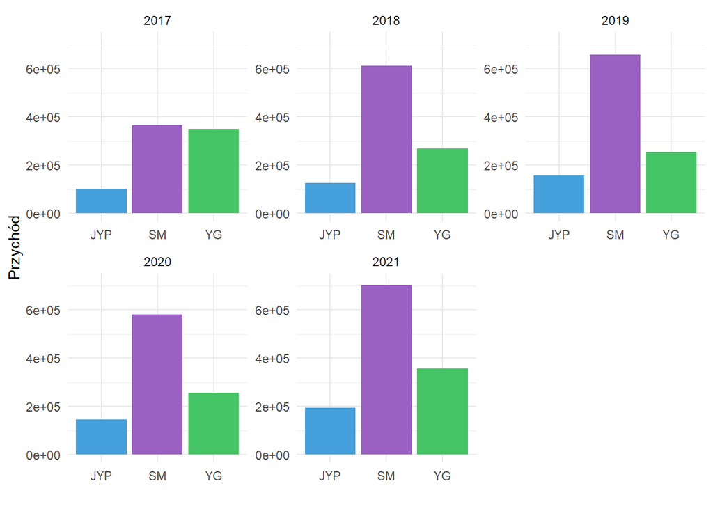

Rysunek 2: Porównanie przychodu “Wielkiej Trójki”

Na podstawie Rysunek 2 wyraźnie widać, że wytwórnia S.M jedynie w roku 2017 miała wyrównany przychód z choć jedną firmą. W pozostałych miała zdecydowaną przewagę.

## Artyści każdej wytwórni

Wytwórnie rozrywkowe mają pod swoją opieką różnego rodzaju artystów: solistów, zespoły, aktorów, producentów czy choreografów. JYP oraz YG posiadają również spółki zależne/podwytwórnie, które jednak nie będą brane pod uwagę.

Tabela 4: Ilość artystów

| Wytwórnia | Soliści | Grupy | Aktorzy | Producenci | Choreografowie |
| --- | --- | --- | --- | --- | --- |
| JYP Entertainment | 5 | 6 | 6 | 28 | 7 |
| S.M Entertainment | 7 | 22 | 10 | 9 | 6 |
| YG Entertainment | 7 | 11 | 31 | 17 |  |

Znikoma ilość aktorów w JYP Entertainment spowodowana jest połączeniem wydziału z rozwijającą się firmą Npio Entertainment. Zdecydowano wtedy, że jedynie szóstka aktorów pozostanie aż do końca ich kontraktu, z pozostałymi umowa została zerwana za porozumieniem stron.

## Nagrody i nominacje

W tej części skupię się jedynie na zespołach k-pop. Na galach zespoły mogą otrzymać nagrodę np. za konkretną piosenkę, album, choreografię, sprzedaż. Dwa zespoły z YG Entertainment zostały pominięte z powodu braku danych.

Tabela 5: Ilość nominacji i wygranych zespołów JYP

|  | 2PM | TWICE | Stray Kids | Itzy |
| --- | --- | --- | --- | --- |
| Ilość wygranych | 34 | 113 | 48 | 32 |
| Ilość nominacji | 88 | 304 | 111 | 107 |

Tabela 6: Ilość nominacji i wygranych zespołów S.M

|  | Aespa | NCT | Red Velvet | EXO | SHINee | Girls' Generation | TVXQ |
| --- | --- | --- | --- | --- | --- | --- | --- |
| Ilość wygranych | 36 | 85 | 58 | 176 | 61 | 125 | 80 |
| Ilość nominacji | 85 | 232 | 218 | 311 | 136 | 237 | 129 |

Tabela 7: Ilość nominacji i wygranych zespołów YG

|  | BIGBANG | AKMU | BLACKPINK | Treasure | WINNER |
| --- | --- | --- | --- | --- | --- |
| Ilość wygranych | 135 | 20 | 92 | 17 | 17 |
| Ilość nominacji | 223 | 82 | 306 | 44 | 82 |

## Dyskografia wytwórni

Poniżej zostanie przedstawione porównanie ilości albumów wydanych przez poszczególne zespoły z każdej z wytwórni, ilość sprzedanych kopii oraz najwyższe notowania albumów studyjnych na listach popularności w amerykańskim tygodniku Billboard *(US World*), na oficjalnej stronie internetowej japońskiego przedsiębiorstwa Oricon Inc. (jap. *Kabushiki-gaisha Orikon*)*(JPN)* oraz koreańskiego Circle Chart, wcześniej znane również jako Gaon Chart *(KOR)*. Powstał on dopiero w lutym 2010 roku jednak część zespołów działała już wcześniej. Z tego powodu niektóre albumy mogą nie posiadać notacji *(oznaczone jako * w tabeli)*. W tabelach wytwórni zespoły zostały podzielone na generacje. Generacjami nazywa się zespoły, które debiutowały w podobnym okresie oraz łączy je podobny styl muzyczny. Najczęściej dzielone są na cztery generacje:

- Generacja pierwsza 1992-2002
- Generacja druga 2003-2010
- Generacja trzecia 2011-2016
- Generacja czwarta 2017- …

Tabela 8: Ilość wydanych albumów przez zespoły JYP

|  | 2PM II | TWICE III | Stray Kids IV | ITZY IV |
| --- | --- | --- | --- | --- |
| Albumy studyjne | 12 | 7 | 3 | 1 |
| Kompilacje | 5 | 11 | 4 | 1 |
| Minialbumy | 2 | 4 | 11 | 6 |
| Single | 27 | 35 | 28 | 8 |

Tabela 9: Ilość wydanych albumów przez zespoły YG

|  | SechKies I | BIGBANG II | AKMU III | WINNER III | BLACKPINK III | TREASURE IV |
| --- | --- | --- | --- | --- | --- | --- |
| Albumy studyjne | 6 | 8 | 3 | 4 | 2 | 1 |
| Kompilacje | 4 | 8 |  | 1 | 1 |  |
| Minialbumy | 1 | 8 | 2 | 4 | 3 | 2 |
| Single | 9 | 36 | 13 | 16 | 12 | 6 |

Tabela 10: Ilość wydanych albumów przez zespoły SM

|  | TVXQ II | Girls’ Generation II | SHINee II | EXO III | Red Velvet III | NCT III | Aespa IV |
| --- | --- | --- | --- | --- | --- | --- | --- |
| Albumy studyjne | 19 | 10 | 12 | 7 | 3 | 3 |  |
| Kompilacje | 4 | 2 | 3 |  | 1 |  |  |
| Minialbumy | 3 | 4 | 6 | 7 | 14 |  | 2 |
| Single | 74 | 29 | 37 | 28 | 28 | 13 | 8 |

### Zespoły wytwórni JYP

Tabela 11: Notacje i sprzedaż albumów studyjnych zespołu 2PM

| Album | KOR | Sprzedane albumy (KOR) | JPN | Sprzedane albumy (JPN) | US world |
| --- | --- | --- | --- | --- | --- |
| 01:59PM | 1 | 57,906 | 16 | 13,369 |  |
| Hands Up | 1 | 117,005 | 17 | 26,482 |  |
| Republic of 2PM |  |  | 4 | 73,510 |  |
| Legend of 2PM |  |  | 1 | 64,291 |  |
| Grown | 1 | 140,982 | 10 | 24,937 | 6 |
| Genesis of 2PM |  |  | 1 | 72,003 |  |
| Go Crazy! | 3 | 72,815 | 18 | 11,358 | 7 |
| 2PM of 2PM |  |  | 1 | 68,147 |  |
| No.5 | 1 | 63,392 | 14 | 11,777 | 3 |
| Galaxy of 2PM |  |  | 1 | 122,685 |  |
| Gentlemen's Game | 1 | 69,678 | 12 | 12,287 | 11 |
| Must | 3 | 143,480 | 4 | 8,187 |  |

Tabela 12: Notacje i sprzedaż albumów studyjnych zespołu Twice

| Album | KOR | Sprzedane albumy (KOR) | JPN | Sprzedane albumy (JPN) | Sprzedane albumy (JPN) | US world |
| --- | --- | --- | --- | --- | --- | --- |
| Twicetagram | 1 | 443,073 | 7 | 132,598 | 3,708 | 1 |
| Eyes Wide Open | 2 | 608,313 | 3 | 57,693 | 2,295 | 2 |
| Formula of Love: O+T=<3 | 1 | 942,050 | 2 | 68,975 |  | 1 |
| BDZ |  |  | 1 | 353,947 | 6,108 |  |
| &Twice |  |  | 1 | 221,575 | 2,379 |  |
| Perfect World |  |  | 2 | 83,445 | 1,625 |  |
| Celebrate |  |  | 2 | 127,393 | 2,320 |  |

Tabela 13: Notacje i sprzedaż albumów studyjnych zespołu Stray Kids

| Album | KOR | Sprzedane albumy (KOR) | JPN | Sprzedane albumy (JPN) | US world |
| --- | --- | --- | --- | --- | --- |
| Go Live | 1 | 605,789 | 6 | 39,911 | 4 |
| Noeasy | 1 | 1,550,043 | 2 | 54,169 | 5 |
| The Sound | TBA |  | TBA |  | TBA |

Album “The Sound” nie zawiera jeszcze notacji, zostanie on dopiero wydany 22 lutego.

Tabela 14: Notacje i sprzedaż albumu studyjnego zespołu Itzy

| Album | KOR | Sprzedane albumy (KOR) | JPN | US world |
| --- | --- | --- | --- | --- |
| Crazy in Love | 1 | 623,059 | 8 | 1 |

### Zespoły wytwórni YG

Tabela 15: Notacje i sprzedaż albumów studyjnych zespołu Sechs Kies

| Album | KOR | Sprzedane albumy (KOR) | US world |
| --- | --- | --- | --- |
| School Byeolgok |  | 1,200,000 |  |
| Welcome To The SechskiesLand |  | 700,000 |  |
| Road Fighter |  | 700,000 |  |
| Special Album |  | 1,000,000 |  |
| Com’Back |  | 700,000 |  |
| Another Light | 2 | 98,775 | 10 |

Tabela 16: Notacje i sprzedaż albumów studyjnych zespołu Big Bang

| Album | KOR | Sprzedane albumy (KOR) | JPN | Sprzedane albumy (JPN) |
| --- | --- | --- | --- | --- |
| Big Bang Vol.1 | 3 | 86,759 |  |  |
| Remember | 5 | 219,572 |  |  |
| Made | 1 | 259,779 | 1 | 138,203 |
| Number 1 |  |  | 13 |  |
| Big Bang |  |  | 3 | 67,285 |
| Big Bang 2 |  |  | 1 | 98,854 |
| Alive |  |  | 3 | 217,000 |
| Made Series |  |  | 1 | 202,600 |

Tabela 17: Notacje i sprzedaż albumów studyjnych zespołu AKMU

| Album | KOR | Sprzedane albumy (KOR) | US world |
| --- | --- | --- | --- |
| Play | 1 | 36,522 | 2 |
| Winter | 8 | 9,910 | 7 |
| Sailing | 4 | 10,531 |  |

Tabela 18: Notacje i sprzedaż albumów studyjnych zespołu Winner

| Album | KOR | Sprzedane albumy (KOR) | JPN | Sprzedane albumy (JPN) | US world |
| --- | --- | --- | --- | --- | --- |
| 2014 S/S | 1 | 92,897 | 2 | 40,835 | 1 |
| Everyday | 1 | 124,264 | 5 | 36,991 | 6 |
| Remember | 3 | 113,346 |  |  |  |
| Our Twenty For |  |  | 5 | 24,009 |  |

Tabela 19: Notacje i sprzedaż albumów studyjnych zespołu Blackpink

| Album | KOR | Sprzedane albumy (KOR) | JPN | Sprzedane albumy (JPN) | usblapi |
| --- | --- | --- | --- | --- | --- |
| The Album | 1 | 1,560,637 | 3 | 66,862 | 2 |
| Born Pink | 1 | 2,640,372 | 3 | 34,475 | 1 |

Tabela 20: Notacje i sprzedaż albumu studyjnego zespołu Treasure

| Album | KOR | Sprzedane albumy (KOR) | JPN | Sprzedane albumy (JPN) |
| --- | --- | --- | --- | --- |
| The First Step: Treasure Effect | 1 | 399,445 | 1 | 130,288 |

### Zespoły wytwórni SM

Tabela 21: Notacje i sprzedaż albumów studyjnych zespołu TVXQ

| Album | KOR | Sprzedane albumy (KOR) | JPN | Sprzedane albumy (JPN) | US world |
| --- | --- | --- | --- | --- | --- |
| Tri-Angle | 35 | 305,343 | 93 |  |  |
| Rising Sun | 34 | 290,809 |  |  |  |
| "O"-Jung.Ban.Hap. | 5 | 468,617 |  |  |  |
| Mirotic | 1 | 603,936 |  |  |  |
| Keep Your Head Down | 1 | 327,120 | 4 | 51,940 |  |
| Catch Me | 1 | 356,208 | 14 | 69,090 | 6 |
| Tense | 1 | 307,537 | 4 | 51,572 | 2 |
| New Chapter #1: The Chance of Love | 1 | 146,354 | 7 | 12,519 |  |
| Heart, Mind and Soul | 68 | 29,947 | 25 | 36,397 |  |
| Five in the Black |  | 25,750 | 10 | 62,362 |  |
| T |  | 56,983 | 4 | 158,524 |  |
| The Secret Code |  |  | 2 | 317,699 |  |
| Tone | 4 | 11,765 | 1 | 331,600 |  |
| Time | 6 | 16,229 | 1 | 298,389 |  |
| Tree | 15 | 33,644 | 1 | 265,013 |  |
| With | 7 | 2,206 | 1 | 266,824 |  |
| Tomorrow |  |  | 1 | 153,262 |  |
| XV |  |  | 1 | 184,201 |  |

Tabela 22: Notacje i sprzedaż albumów studyjnych zespołu Girls’ Generation

| Album | KOR | Sprzedane albumy (KOR) | JPN | Sprzedane albumy (JPN) | US world |
| --- | --- | --- | --- | --- | --- |
| Girls' Generation |  | 174,545 |  |  |  |
| Oh! | 1 | 247,520 | 54 | 9,318 |  |
| The Boys | 1 | 471,620 | 2 | 107,800 | 2 |
| I Got a Boy | 1 | 318,886 | 7 | 54,000 | 1 |
| Lion Heart | 1 | 165,361 | 11 | 21,500 | 1 |
| Holiday Night | 2 | 178,407 | 16 | 11,000 | 1 |
| Forever 1 | 2 | 292,150 | 9 | 12,033 |  |
| Girls' Generation |  | 29,000 | 1 | 871,000 |  |
| Girls & Peace |  | 1,600 | 3 | 204,000 |  |
| Love & Peace |  | 1,700 | 1 | 171,000 |  |

Tabela 23: Notacje i sprzedaż albumów studyjnych zespołu Shinee

| Album | KOR | Sprzedane albumy (KOR) | JPN | Sprzedane albumy (JPN) | US world |
| --- | --- | --- | --- | --- | --- |
| The Shinee World |  | 69,246 |  |  |  |
| Lucifer | 1 | 150,710 | 14 | 19,283 |  |
| The Misconceptions of Us | 1 | 184,719 | 10 | 24,376 | 2 |
| Odd | 1 | 193,412 | 6 | 41,070 | 1 |
| 1 of 1 | 1 | 179,027 | 11 | 32,561 | 2 |
| The Story of Light | 1 | 116,152 | 7 | 13,147 | 4 |
| Don't Call Me | 1 | 313,309 | 7 | 44,711 | 7 |
| The First | 3 | 8,254 | 4 | 99,565 |  |
| Boys Meet U |  |  | 2 | 69,010 |  |
| I'm Your Boy | 9 | 3,662 | 1 | 61,357 |  |
| D×D×D |  |  | 1 | 61,263 |  |
| Five |  |  | 3 | 84,281 |  |

Tabela 24: Notacje i sprzedaż albumów studyjnych zespołu EXO

| Album | KOR | Sprzedane albumy (KOR) | JPN | Sprzedane albumy (JPN) | US world | Sprzedane albumy (US world) |
| --- | --- | --- | --- | --- | --- | --- |
| XOXO | 1 | 579,874 | 9 | 148,000 | 1 | 6,000 |
| Exodus | 1 | 808,358 | 4 | 83,226 | 1 | 15,000 |
| Ex'Act | 1 | 836,116 | 5 | 61,918 | 2 |  |
| The War | 1 | 1,132,625 | 7 | 51,285 | 1 | 11,000 |
| Don't Mess UpMy Tempo | 1 | 1,445,329 | 3 | 67,889 | 1 | 50,000 |
| Obsession | 1 | 843,305 | 16 | 24,275 | 1 | 25,000 |
| Countdown |  |  | 1 | 123,912 | 4 |  |

Tabela 25: Notacje i sprzedaż albumów studyjnych zespołu Red Velvet

| Album | KOR | Sprzedane albumy (KOR) | JPN | Sprzedane albumy (JPN) | US world | Sprzedane albumy (US world) |
| --- | --- | --- | --- | --- | --- | --- |
| The Red | 1 | 109,573 | 47 | 4,478 | 1 | 3,000 |
| Perfect Velvet | 2 | 155,463 | 20 | 12,799 | 1 | 3,000 |
| Bloom |  |  | 5 | 17,811 |  |  |

Tabela 26: Notacje i sprzedaż albumów studyjnych zespołu NCT

| Album | KOR | Sprzedane albumy (KOR) | JPN | Sprzedane albumy (JPN) | US world | Sprzedane albumy (US world) |
| --- | --- | --- | --- | --- | --- | --- |
| NCT 2018 Empathy | 2 | 640,535 | 10 | 15,757 | 5 | 1,000 |
| NCT 2020 Resonance | 1 | 1,647,895 | 2 | 149,855 | 1 | 146,000 |
| Universe | 1 | 1,837,313 | 1 | 84,158 | 1 | 20,000 |

## Dane

Wykorzystane dane zostały pobrane z niżej wymienionych stron:

- https://www.wsj.com/market-data/quotes/KR/035900/financials/annual/income-statement
- https://www.wsj.com/market-data/quotes/KR/XKRX/041510/financials/annual/income-statement
- https://www.wsj.com/market-data/quotes/KR/XKRX/122870/financials/annual/income-statement
- https://en.wikipedia.org/wiki/JYP_Entertainment#Artists
- https://en.wikipedia.org/wiki/List_of_awards_and_nominations_received_by_2PM
- https://en.wikipedia.org/wiki/Twice#Awards_and_achievements
- https://en.wikipedia.org/wiki/List_of_awards_and_nominations_received_by_Stray_Kids
- https://en.wikipedia.org/wiki/List_of_awards_and_nominations_received_by_Itzy
- https://en.wikipedia.org/wiki/YG_Entertainment
- https://en.wikipedia.org/wiki/List_of_awards_and_nominations_received_by_Big_Bang
- https://en.wikipedia.org/wiki/List_of_awards_and_nominations_received_by_AKMU
- https://en.wikipedia.org/wiki/List_of_awards_and_nominations_received_by_Winner
- https://en.wikipedia.org/wiki/List_of_awards_and_nominations_received_by_Blackpink
- https://en.wikipedia.org/wiki/Treasure_(band)#Awards_and_nominations
- https://en.wikipedia.org/wiki/SM_Entertainment
- https://en.wikipedia.org/wiki/List_of_awards_and_nominations_received_by_TVXQ
- https://en.wikipedia.org/wiki/List_of_awards_and_nominations_received_by_Girls%27_Generation
- https://en.wikipedia.org/wiki/List_of_awards_and_nominations_received_by_Shinee
- https://en.wikipedia.org/wiki/List_of_awards_and_nominations_received_by_Exo
- https://en.wikipedia.org/wiki/List_of_awards_and_nominations_received_by_Red_Velvet
- https://en.wikipedia.org/wiki/List_of_awards_and_nominations_received_by_NCT
- https://en.wikipedia.org/wiki/List_of_awards_and_nominations_received_by_Aespa
- https://en.wikipedia.org/wiki/2PM_discography
- https://en.wikipedia.org/wiki/Twice_albums_discography
- https://en.wikipedia.org/wiki/Stray_Kids_discography
- https://en.wikipedia.org/wiki/Itzy_discography
- https://en.wikipedia.org/wiki/Big_Bang_discography
- https://en.wikipedia.org/wiki/Sechs_Kies_discography
- https://en.wikipedia.org/wiki/AKMU_discography
- https://en.wikipedia.org/wiki/Winner_discography
- https://en.wikipedia.org/wiki/Blackpink_discography
- https://en.wikipedia.org/wiki/Treasure_discography
- https://en.wikipedia.org/wiki/TVXQ_albums_discography
- https://en.wikipedia.org/wiki/Girls%27_Generation_discography
- https://en.wikipedia.org/wiki/Shinee_discography
- https://en.wikipedia.org/wiki/Exo_discography
- https://en.wikipedia.org/wiki/Red_Velvet_discography
- https://en.wikipedia.org/wiki/NCT_discography